# Homework 1

Andrew Wong, Heather Shapiro, Jessie Li, Dipesh Gautam

# Background

The 2014 FIFA World Cup took place during the summer of 2014 in Brazil. There were 32 teams involved in the Cup, and throughout the course of the tournament, over 172 goals, excluding penalty shootouts, were scored. While working with semi-structured data on the World Cup, we were able to understand and visualize the results and breakdowns by countries, players, and even goal position.

### Task 1: Parse the Data

The stringr library is loaded to give us the `str_match_all` function, which returns a matrix with one column for the complete match and one column for each group matching the specified criteria. The `unlist` function used in conjunction with the “seq” function draws information from the second column of the aforementioned matrix. It does so by retrieving the information at position 2 and continuing on to grab every other item until the end of the matrix.

```r
d <- readLines("~cr173/Sta523/data/world_cup_goals_raw.txt")
library(stringr)

ID <- unlist(str_match_all(d," id=\"g([0-9]*)\""))[seq(2,386,2)]
pointInGoal <- unlist(str_match_all(d," pig=\"([0-9]*)\""))[seq(2,386,2)]
class <- unlist(str_match_all(d," class=\"([a-z ]*)\""))[seq(2,386,2)]
playerID <- unlist(str_match_all(d," pid=\"([0-9]*)\""))[seq(2,386,2)]
matchID <- unlist(str_match_all(d," mid=\"([0-9]*)\""))[seq(2,386,2)]
name <- unlist(str_match_all(d, ignore.case(" pname=\"([a-z -]*[^ascii]*[a-z -&;'?]*)\"")))[seq(2,386,2)]
team <- unlist(str_match_all(d, ignore.case(" pteam=\"([a-z &;']*)\"")))[seq(2,386,2)]
time <- unlist(str_match_all(d, " ptime=\"([0-9]*)\""))[seq(2,386,2)]
addTime <- unlist(str_match_all(d, " paddtime=\"([0-9]*)\""))[seq(2,386,2)]
goalType <- unlist(str_match_all(d, ignore.case(" ptype=\"([a-z]*[a-z -]*)\"")))[seq(2,386,2)]
teamImg <- unlist(str_match_all(d," pteamimg=\"([a-z /.]*)\""))[seq(2,386,2)]
pMatch <- unlist(str_match_all(d," pmatch=\"([0-9]*)\""))[seq(2,386,2)]
horiLoc <- 1000-as.numeric(unlist(str_match_all(d, "left: ([0-9]*)px"))[seq(2,386,2)])
horiLoc[2:193] <- unlist(str_match_all(d, "right: ([0-9]*)px"))[seq(2,384,2)]
vertLoc <- unlist(str_match_all(d, " top: ([0-9]*)px"))[seq(2,386,2)]

Data <- data.frame(ID = ID,
  pointInGoal = pointInGoal,
  class = class,
  playerID = playerID,
  matchID = matchID,
  name = name,
  team = team,
  time = time,
  addTime = addTime,
  goalType = goalType,
  teamImg = teamImg,
  pMatch = pMatch,
  horiLoc = horiLoc,
  vertLoc = vertLoc)
```

### Task 2: Visualize the Data

With all of the data from the World Cup, one relationship we deemed important was the number of goals scored per country.

In order to visualize the parsed data from Task 1, we needed to create a modified data frame with a cleaner product. The new data frame excluded goals that were scored for a player’s own team as well as penalty kicks. In addition, we were able to change the name for Ivory Coast and South Korea to match the geocode database, which determined what country each team and player represented.

#### Checking for installed packages

```
##
##  '/tmp/RtmpyjqErl/downloaded_packages'
```

```
##
##  '/tmp/RtmpyjqErl/downloaded_packages'
```

[output not shown]

```
##
##  '/tmp/RtmpyjqErl/downloaded_packages'
```

```
## ### Welcome to rworldmap ###
## For a short introduction type :   vignette('rworldmap')
```

#### Creating the modified dataframes

```r
# Create new dataframe by removing "Own goal" and class with "ispen"
DataModified <-Data[Data$goalType!="Own goal" & grepl(".+ispen$", class)==FALSE, ]

# Change the name for Ivory Coast and South Korea to match the geocode database

DataModified$team <- as.character(DataModified$team)
DataModified$team[DataModified$team=="C&ocirc;te d'Ivoire"]= "Ivory Coast"
DataModified$team[DataModified$team=="Korea Republic"]= "South Korea"

# Create a new dataframe with total goals scored by players from each country
Countries <- as.data.frame(count(DataModified$team))
colnames(Countries) <- c("name","Goals")

# Add latitude and longitude data for all 32 countries to Countries data frame. First, check if the file with the location data exists, if not download the data and write to the file.
Countries$name <- as.character(Countries$name)
if (!file.exists("~/Team2/HW1/LocationData.csv")){
    ll.Countries <- geocode(Countries$name)
    write.csv(as.data.frame(ll.Countries), file="~/Team2/HW1/LocationData.csv")
    }

ll.Countries <- read.csv("~/Team2/HW1/LocationData.csv")
Countries$lon <- ll.Countries$lon
Countries$lat <- ll.Countries$lat
```

#### Regional and World Maps of Goals Scored per Country

The maps generated below, show the world as well each continent separated as regions. The size of the bubbles indicate the numbers of goals each country scored. For instance, not surprisingly, Germany scored 18 goals, and thus, has the largest bubble on the maps. A for loop was used to create one world map, and six regional maps.

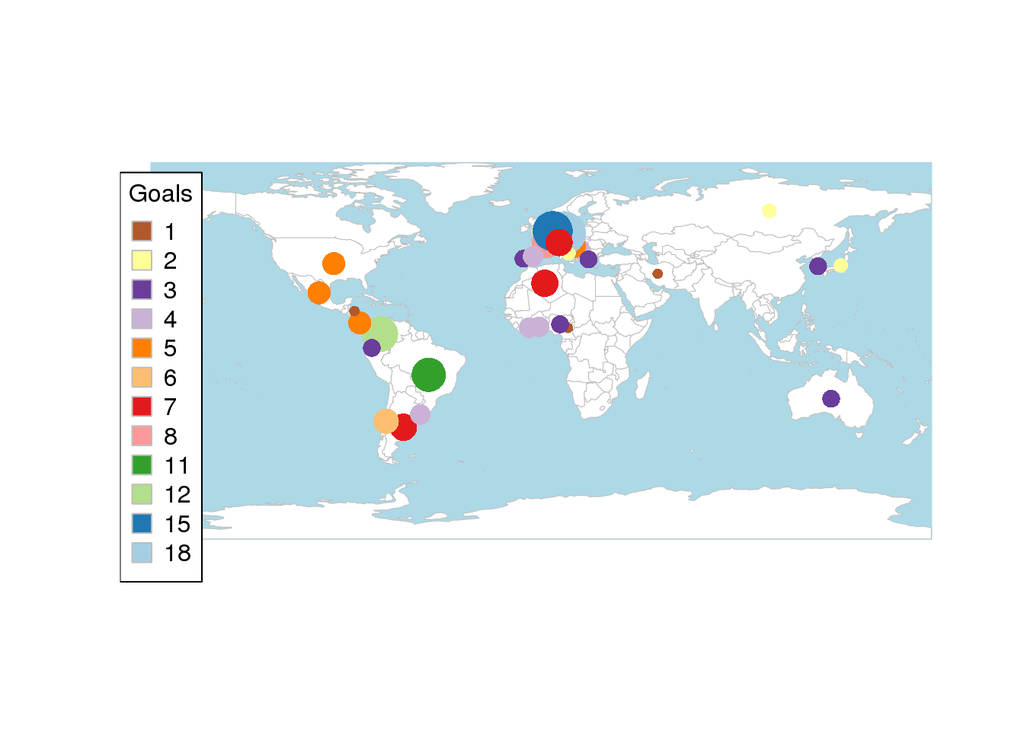

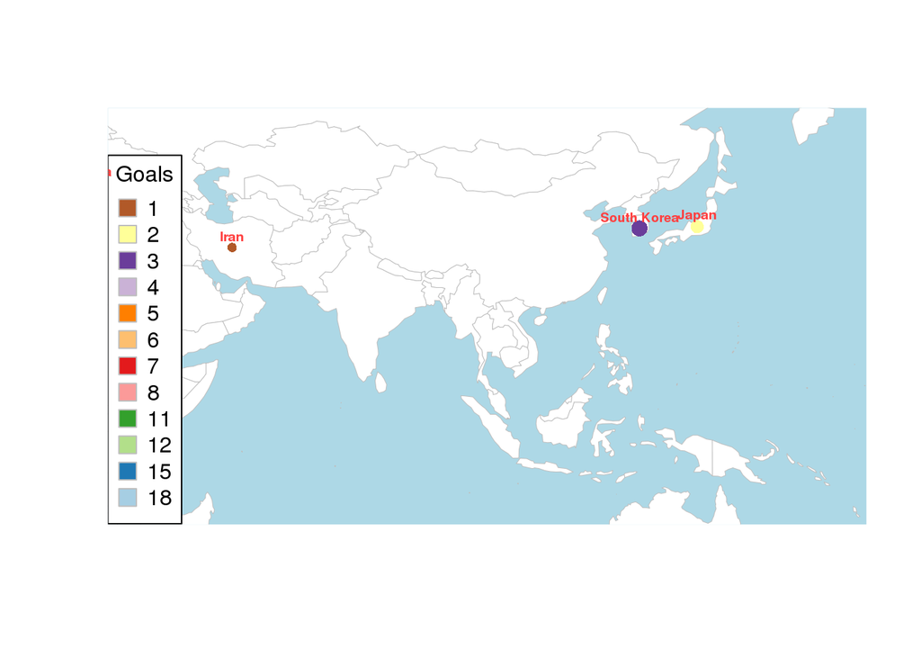

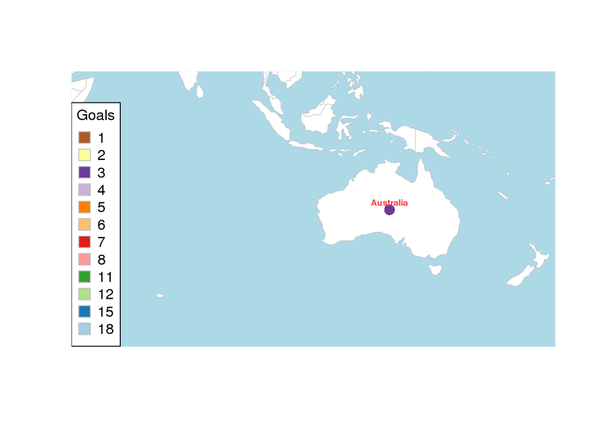

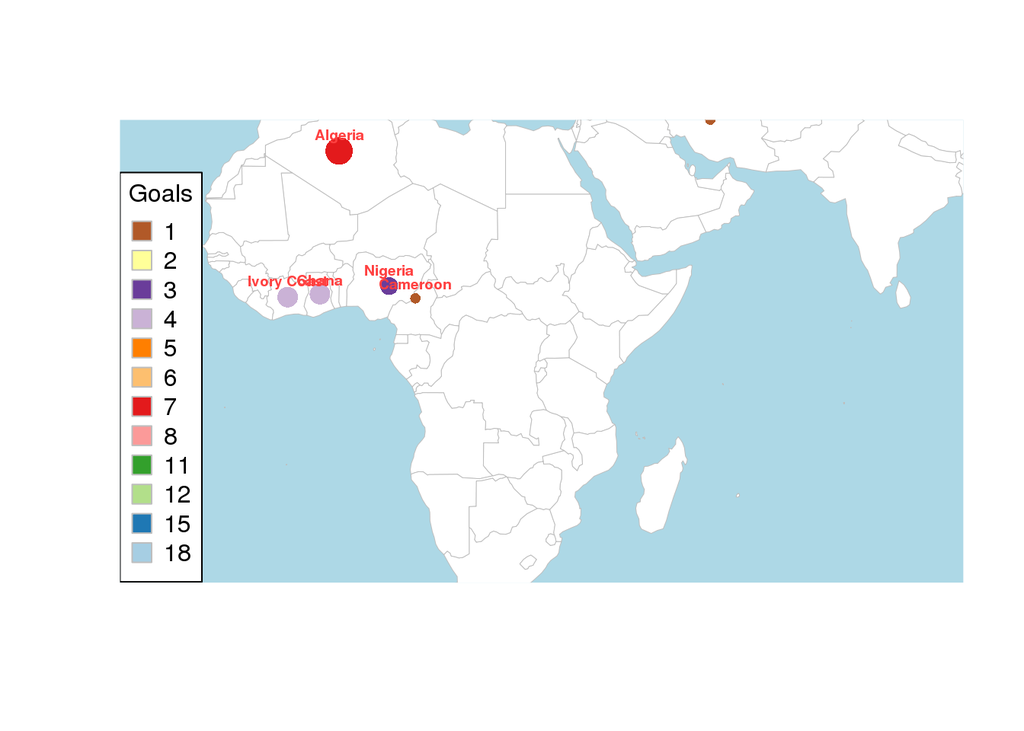

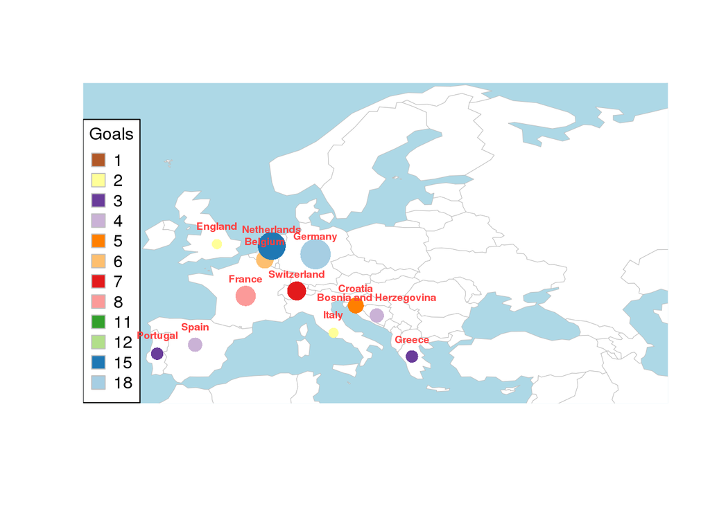

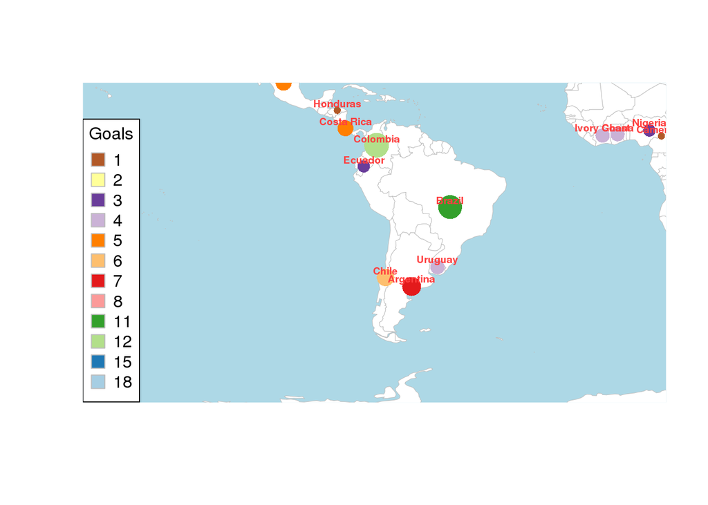

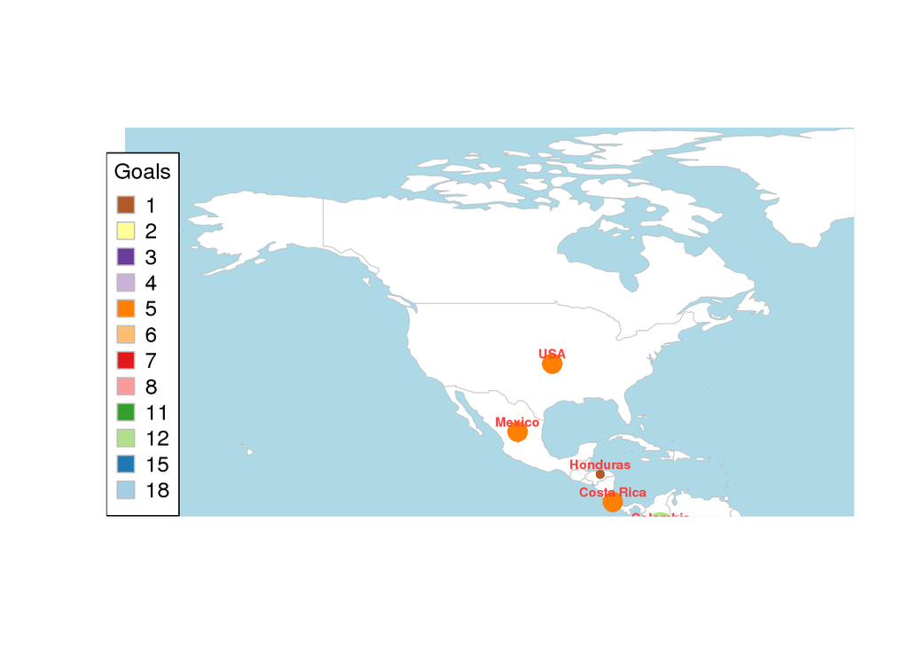

#### Height versus the number of goals scored

[figure not shown]

```r
if("jsonlite" %in% rownames(installed.packages()) == FALSE) {install.packages("jsonlite",  repos="http://cran.rstudio.com/")}
library(jsonlite)
```

### Task 3: Translate

The original data frame built from the raw data of `world_cup_goals_raw.txt` has been converted into valid, well-formatted JSON with country to player to goals hierarchy. This hierarchy relates to the visualization we did for task 2 as it looks as goals scored by each country. It further looks at who scored the goals for each country and the number of goals scored by each player.

Prettify function was used to add indentation to JSON formatted data and make it readable. The output was truncated to show keep the output at reasonable length.

```r
countriesList <- as.data.frame(unique(Data$team))
colnames(countriesList) <- c("country")
goalDetails <-rep(NA, 10)
goal <- list(goalDetails)
player <-list( list( list(), list(), goal))
jsonList <-list( list( list( list(),list(), player)))

for (i in 1:32){

    subset <- Data[Data$team == as.character(countriesList$country[i]),]
    goal <-list(goalDetails)
    player <- list( list( list(), list(), goal))
    jsonList[i] <- list( list( list(),list(), player))
    playerList <- as.data.frame(unique(subset$name))
    colnames(playerList) <- c("name")

    for (j in 1:nrow(playerList)){
        playerSubset <- subset[subset$name == as.character(playerList$name[j]),]
        goal <- rep( list(goalDetails), nrow(playerSubset) )
        player[j] <- list( list( list(), list(), goal))
        for (k in 1:nrow(playerSubset)){
            goal[[k]]<-list("goalType"=as.character(playerSubset$goalType[k])
                      ,"class"=as.character(playerSubset$class[k])
                      ,"time"=as.character(playerSubset$time[k])
                      ,"addTime"=as.character(playerSubset$addTime[k])
                      ,"vertLoc"=as.character(playerSubset$vertLoc[k])
                      ,"horiLoc"=as.character(playerSubset$horiLoc[k])
                      ,"pointInGoal"=as.character(playerSubset$pointInGoal[k])
                      ,"matchId"=as.character(playerSubset$matchID[k])
                      ,"pMatch"=as.character(playerSubset$pMatch[k])
                      ,"ID"=as.character(playerSubset$ID[k]))
            }
        player[j] <- list(list("name"=as.character(playerSubset$name[1]),
                        "playerID"= as.character(playerSubset$playerID[1])
                        ,"goals"=goal))
        }
    jsonList[i] <- list(list(list("Country"=as.character(subset$team[1])
                      ,"Flag"=as.character(subset$teamImg[1])
                      , "goalScorers"=player)))
    }
jsonConverted <- rjson::toJSON(jsonList)
jsonPrettified <- prettify(jsonConverted)
```

```
## [
##     [
##         {
##             "Country": "Cameroon",
##             "Flag": "flags/cmr.png",
##             "goalScorers": [
##                 {
##                     "name": "Joel Matip",
##                     "playerID": "346",
##                     "goals": [
##                         {
##                             "goalType": "goal",
##                             "class": "goal cmr ",
##                             "time": "26",
##                             "addTime": "0",
##                             "vertLoc": "22",
##                             "horiLoc": "495",
##                             "pointInGoal": "92",
##                             "matchId": "1",
##                             "pMatch": "1",
##                             "ID": "1"
##                         }
##                     ]
##                 }
##             ]
##         }
##     ],
##     [
##         {
##             "Country": "Brazil",
##             "Flag": "flags/bra.png",
##             "goalScorers": [
##                 {
##                     "name": "Neymar",
##                     "playerID": "21",
##                     "goals": [
##                         {
##                             "goalType": "goal",
##                             "class": "goal bra ",
##                             "time": "17",
```

[output cut: 347 more lines]

```
##                         }
##                     ]
##                 },
##                 {
##                     "name": "Stefan de Vrij",
##                     "playerID": "708",
##                     "goals": [
##                         {
##                             "goalType": "goal",
##                             "class": "goal ned ",
##                             "time": "65",
##                             "addTime": "0",
##                             "vertLoc": "6",
##
## ...
```